# 영화 ‘캡틴마블’ 네이버 영화 리뷰란 분석 보고서

임도균

2019 7 9

## 주제 선정

영화 ’캡틴마블’의 네이버 영화 리뷰란을 분석해보기로 하였다.  
[캡틴 마블:네이버 영화](https://movie.naver.com/movie/bi/mi/basic.nhn?code=132623#tab)  
위 링크의 HTML 파일을 분석하여 리뷰란은 iframe 태그로 작성되어있었고, Python을 이용하여 1000개의 페이지를 크롤링하였다.

## 분석과정

### 데이터 처리

데이터 처리는 R을 사용하였다. KoNLP를 사용하여 데이터를 분석하였다.  
사용한 라이브러리는 다음과 같다.

```r
library(KoNLP)
library(stringr)
library(dplyr)
```

```r
library(wordcloud2)

useSejongDic()
```

```
## Backup was just finished!
## 370957 words dictionary was built.
```

데이터 전처리

```r
comment_datas <- read.csv("data/movie_comment.csv", header = T, fileEncoding="UTF-8")
comment_df <- comment_datas %>% select('cmt')

comment_str <- toString(comment_df)
comment_list <- as.list(comment_df)

comment_str <- paste(unlist(comment_list$cmt), collapse='')

words <- sapply(comment_str, extractNoun, USE.NAMES = F)

words_filtered <- Filter(function(x) {nchar(x) <= 15}, words)
words_filtered <- str_replace_all(words_filtered, "[^[:alpha:]]", "")  # 한글, 영어외는 삭제

words_filtered <- gsub("영화", "", words_filtered)
words_filtered <- gsub("관람객", "", words_filtered)
words_filtered <- gsub("점", "", words_filtered)
words_filtered <- gsub("것", "", words_filtered)
words_filtered <- gsub("이", "", words_filtered)
words_filtered <- gsub("점", "", words_filtered)
words_filtered <- gsub("들", "", words_filtered)
words_filtered <- gsub("듯", "", words_filtered)
words_filtered <- gsub("평", "", words_filtered)
words_filtered <- gsub("한", "", words_filtered)
words_filtered <- gsub("수", "", words_filtered)
words_filtered <- gsub("중", "", words_filtered)
words_filtered <- gsub("만", "", words_filtered)
words_filtered <- gsub("나", "", words_filtered)
words_filtered <- gsub("별", "", words_filtered)
words_filtered <- gsub("데", "", words_filtered)
words_filtered <- gsub("뭐", "", words_filtered)
words_filtered <- gsub(" ", "", words_filtered)

write(unlist(words_filtered),"data/filtered_comment.txt")
read_filtered_words <- read.table("data/filtered_comment.txt")
table_words <- table(read_filtered_words)
```

```r
nrow(table_words)
```

```
## [1] 15868
```

#### wordcloud

```r
wordcount <- head(sort(table_words,decreasing=T), 30)
wordcloud2(wordcount)
```

[interactive chart not shown]

## 분석 I

#### 단어 빈도수 1 ~ 15 위

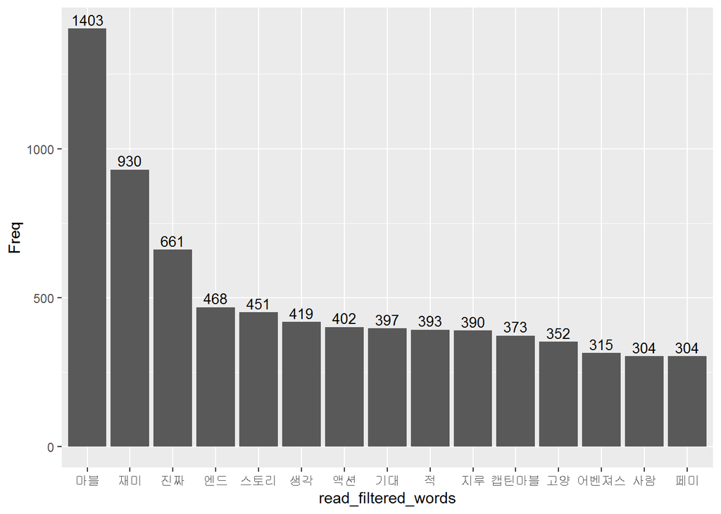

```r
library(ggplot2)

df <- as.data.frame(wordcount)

ggplot(data=head(df, 15), aes(x=read_filtered_words, y=Freq)) +
    geom_bar(stat='identity') +
    geom_text(aes(label=Freq), vjust=-0.3, size=3.5)
```

#### 단어 빈도수 16 ~ 30 위

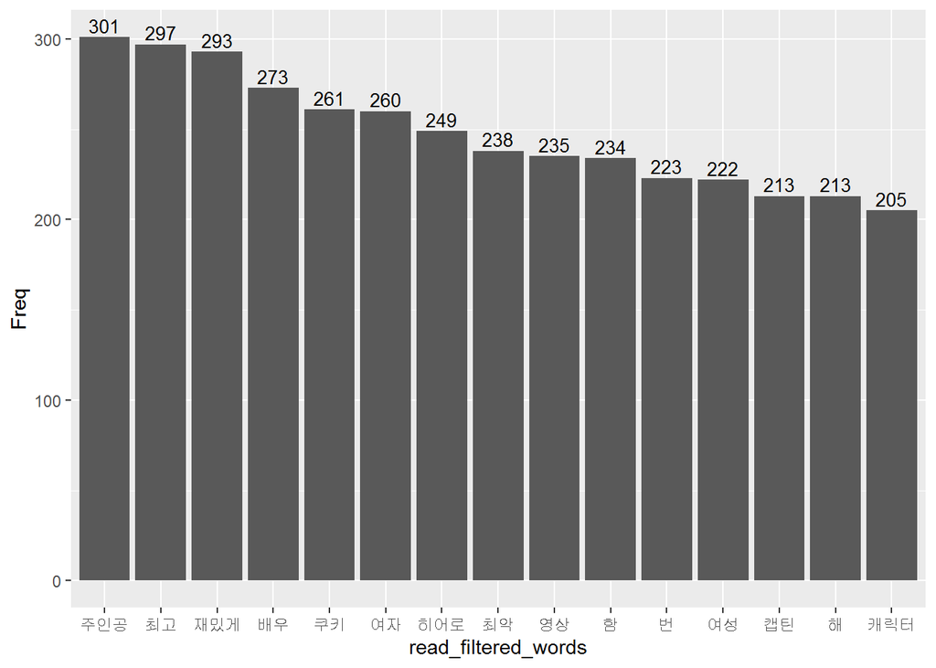

```r
ggplot(data=tail(df, 15), aes(x=read_filtered_words, y=Freq)) +
    geom_bar(stat='identity') +
    geom_text(aes(label=Freq), vjust=-0.3, size=3.5)
```

## 분석 II

이번 분석에서 사용한 데이터는 댓글과 작성시간으로 구분할 수 있다.  
하지만 네이버 영화의 댓글 그래프를 보면 성별과 연령, 댓글 작성시간이라는 데이터가 있다.

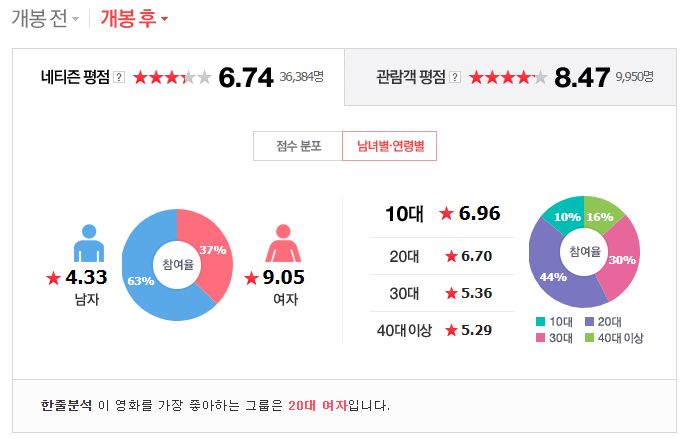

## 데이터 분석 개선점

### 데이터

#### 다른 데이터

네이버 영화 리뷰는 2019년 7월 9일 기준 약 36,000건인 반면에 CGV의 평가 관람객 수는 약 110,000명으로 3배 넘게 차이나는 모습을 볼 수 있다. 여러 사이트의 리뷰를 기준으로 하여 분석할 수 있을 것이다.

### 통계

위의 데이터로 통계와 데이터 과학에 관련된 분석은 하지 못했다.

### 소스코드

#### 크롤링

웹페이지의 소스 분석을 통해 리뷰가 저장된 서버에서 주요 데이터만 갖고오는 방법을 통해 효율적인 크롤링할 수 있다.  
http get 요청을 batch 처리하여 효율적인 데이터 처리를 할 수 있다.

#### 데이터 분석

R을 사용하였고 R과 utf-8의 인코딩 문제로 시간을 버렸는데, Python의 데이터 분석을 보면 가독성도 좋고 디버깅과 프로젝트 관리가 더 쉬울 것이다.

#### wordcloud

wordcloud와 r 파일 인코딩 때문에 코드의 품질이 떨어지고 삽질도 많이 했다.  
특히 wordcloud2 패키지의 이미지의 모양대로 wordcloud를 그려주는 기능을 사용하려 하였으나 함수의 문제로 사용하지 못하였다.  
python의 wordloud 오픈소스 패키지를 사용하면 인상깊은 wordcloud를 제작하여 보다 효과적인 보고서를 작성할 수 있을 것이다.